# DivEMT: Neural Machine Translation Post-Editing Effort Across Typologically Diverse Languages

## 4.5 LMER: Interactions of Fixed Effects

```r
te.lmer4a = lmer(time.l ~ src_len_chr.s + lang_id + task_type * trial.s + (1|subject_id) + (1|document_id/item_id), mydf, REML=F)
summary(te.lmer4a)
```

```
## Linear mixed model fit by maximum likelihood  ['lmerMod']
## Formula: time.l ~ src_len_chr.s + lang_id + task_type * trial.s + (1 |
##     subject_id) + (1 | document_id/item_id)
##    Data: mydf
##
##      AIC      BIC   logLik deviance df.resid
##  17031.7  17142.4  -8499.9  16999.7     7418
##
## Scaled residuals:
##     Min      1Q  Median      3Q     Max
## -6.4664 -0.5439 -0.0204  0.5590  5.4510
##
## Random effects:
##  Groups              Name        Variance Std.Dev.
##  item_id:document_id (Intercept) 0.05830  0.2415
##  document_id         (Intercept) 0.04049  0.2012
##  subject_id          (Intercept) 0.08939  0.2990
##  Residual                        0.52919  0.7275
## Number of obs: 7434, groups:
## item_id:document_id, 413; document_id, 107; subject_id, 18
##
## Fixed effects:
##                      Estimate Std. Error t value
## (Intercept)           5.03153    0.17578  28.624
## src_len_chr.s         0.38100    0.01672  22.790
## lang_idara           -0.49443    0.24586  -2.011
## lang_idita           -0.42192    0.24587  -1.716
## lang_idnld           -0.87494    0.24586  -3.559
## lang_idtur           -0.86539    0.24586  -3.520
## lang_idvie           -0.15803    0.24586  -0.643
## task_typepe1         -0.70066    0.02097 -33.411
## task_typepe2         -0.34478    0.02094 -16.469
## trial.s               0.05411    0.01924   2.813
## task_typepe1:trial.s -0.08899    0.02137  -4.164
## task_typepe2:trial.s -0.05727    0.02134  -2.683
##
## Correlation of Fixed Effects:
##             (Intr) src__. lng_dr lang_dt lng_dn lng_dtr lng_dv tsk_t1 tsk_t2
## src_ln_chr.  0.000
## lang_idara  -0.699  0.000
## lang_idita  -0.699  0.000  0.500
## lang_idnld  -0.699  0.000  0.500  0.500
## lang_idtur  -0.699  0.000  0.500  0.500   0.500
## lang_idvie  -0.699  0.000  0.500  0.500   0.500  0.500
## task_typep1 -0.060 -0.001  0.000  0.000   0.000  0.000   0.000
## task_typep2 -0.060 -0.001  0.000  0.000   0.000  0.000   0.000  0.510
## trial.s     -0.011 -0.007  0.000 -0.004  -0.004  0.000  -0.001  0.149  0.142
## tsk_typp1:.  0.003 -0.003  0.000  0.008   0.008  0.000   0.001 -0.015 -0.050
## tsk_typp2:.  0.003 -0.003  0.000  0.009   0.006  0.000   0.001 -0.052 -0.023
##             tril.s ts_1:.
## src_ln_chr.
## lang_idara
## lang_idita
## lang_idnld
## lang_idtur
## lang_idvie
## task_typep1
## task_typep2
## trial.s
## tsk_typp1:. -0.488
## tsk_typp2:. -0.495  0.520
```

```r
AIC(te.lmer3) - AIC(te.lmer4a) #14. Translators get faster in PE, but slower in HT!
```

```
## [1] 13.65342
```

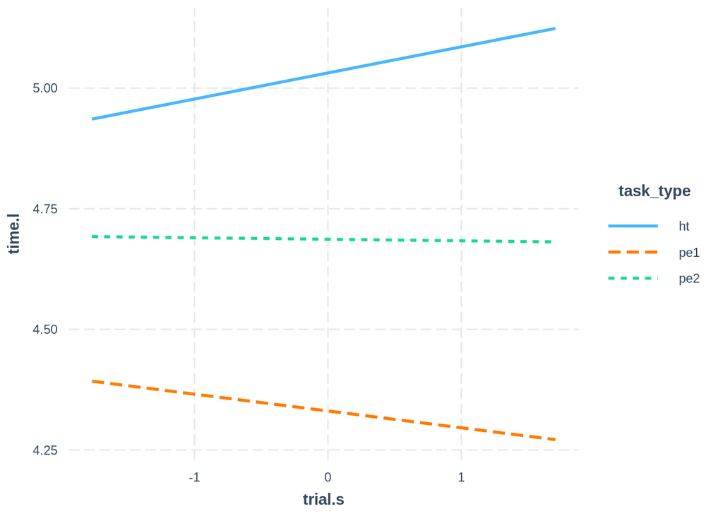

```r
iplot_te_task_trial <- interact_plot(te.lmer4a, pred = trial.s, modx = task_type)
iplot_te_task_trial + theme(axis.title = element_text(family = "Arial"),
           legend.text = element_text(family = "Arial"),
           legend.title = element_text(family = "Arial"),
           strip.text = element_text(family = "Arial"),
           axis.text.x = element_text(family = "Arial"),
           axis.text.y = element_text(family = "Arial"))
```

The model with the interaction between task_type and trial number is better. The interaction is significant.

Figure: Translators get faster in PE, but slower in HT

```r
te.lmer4b = lmer(time.l ~ src_len_chr.s + lang_id * task_type + trial.s + (1|subject_id) + (1|document_id/item_id), mydf, REML=F)
summary(te.lmer4b)
```

```
## Linear mixed model fit by maximum likelihood  ['lmerMod']
## Formula: time.l ~ src_len_chr.s + lang_id * task_type + trial.s + (1 |
##     subject_id) + (1 | document_id/item_id)
##    Data: mydf
##
##      AIC      BIC   logLik deviance df.resid
##  16880.9  17046.9  -8416.5  16832.9     7410
##
## Scaled residuals:
##     Min      1Q  Median      3Q     Max
## -6.5313 -0.5538 -0.0261  0.5572  5.5820
##
## Random effects:
##  Groups              Name        Variance Std.Dev.
##  item_id:document_id (Intercept) 0.05892  0.2427
##  document_id         (Intercept) 0.03581  0.1892
##  subject_id          (Intercept) 0.08900  0.2983
##  Residual                        0.51734  0.7193
## Number of obs: 7434, groups:
## item_id:document_id, 413; document_id, 107; subject_id, 18
##
## Fixed effects:
##                          Estimate Std. Error t value
## (Intercept)              4.927181   0.177219  27.803
## src_len_chr.s            0.380992   0.016601  22.950
## lang_idara              -0.481361   0.248678  -1.936
## lang_idita              -0.113083   0.248743  -0.455
## lang_idnld              -0.540590   0.248725  -2.173
## lang_idtur              -0.787409   0.248685  -3.166
## lang_idvie              -0.204130   0.248677  -0.821
## task_typepe1            -0.503992   0.050077 -10.064
## task_typepe2            -0.228366   0.050077  -4.560
## trial.s                 -0.029003   0.015918  -1.822
## lang_idara:task_typepe1 -0.092901   0.070829  -1.312
## lang_idita:task_typepe1 -0.469165   0.071349  -6.576
## lang_idnld:task_typepe1 -0.600732   0.071332  -8.422
## lang_idtur:task_typepe1 -0.218594   0.070906  -3.083
## lang_idvie:task_typepe1  0.138391   0.070817   1.954
## lang_idara:task_typepe2  0.053288   0.070829   0.752
## lang_idita:task_typepe2 -0.432602   0.071445  -6.055
## lang_idnld:task_typepe2 -0.379606   0.071166  -5.334
## lang_idtur:task_typepe2 -0.016041   0.070906  -0.226
## lang_idvie:task_typepe2  0.003769   0.070815   0.053
```

```
##
## Correlation matrix not shown by default, as p = 20 > 12.
## Use print(x, correlation=TRUE)  or
##     vcov(x)        if you need it
```

```r
AIC(te.lmer3) - AIC(te.lmer4b) # 164. PE is not equally useful in all languages
```

```
## [1] 164.4456
```

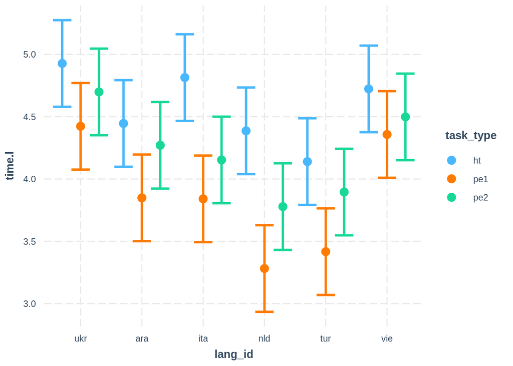

```r
iplot_te_task_trial <- cat_plot(te.lmer4b, pred = lang_id, modx = task_type)
iplot_te_task_trial + theme(axis.title = element_text(family = "Arial"),
           legend.text = element_text(family = "Arial"),
           legend.title = element_text(family = "Arial"),
           strip.text = element_text(family = "Arial"),
           axis.text.x = element_text(family = "Arial"),
           axis.text.y = element_text(family = "Arial"))
```

The interaction between tasktype and lang_id leads to a better model.

```r
te.lmer4c = lmer(time.l ~ task_type * `src_len_chr.s` + trial.s + (1|subject_id) + (1|document_id/item_id), mydf, REML=F)
summary(te.lmer4c)
```

```
## Linear mixed model fit by maximum likelihood  ['lmerMod']
## Formula: time.l ~ task_type * src_len_chr.s + trial.s + (1 | subject_id) +
##     (1 | document_id/item_id)
##    Data: mydf
##
##      AIC      BIC   logLik deviance df.resid
##  17052.1  17128.2  -8515.1  17030.1     7423
##
## Scaled residuals:
##     Min      1Q  Median      3Q     Max
## -6.4809 -0.5456 -0.0223  0.5545  5.4629
##
## Random effects:
##  Groups              Name        Variance Std.Dev.
##  item_id:document_id (Intercept) 0.05825  0.2413
##  document_id         (Intercept) 0.04215  0.2053
##  subject_id          (Intercept) 0.19487  0.4414
##  Residual                        0.53023  0.7282
## Number of obs: 7434, groups:
## item_id:document_id, 413; document_id, 107; subject_id, 18
##
## Fixed effects:
##                             Estimate Std. Error t value
## (Intercept)                 4.567759   0.107653  42.431
## task_typepe1               -0.702423   0.020964 -33.506
## task_typepe2               -0.348998   0.020931 -16.673
## src_len_chr.s               0.373286   0.020588  18.131
## trial.s                     0.012389   0.015967   0.776
## task_typepe1:src_len_chr.s  0.001518   0.020727   0.073
## task_typepe2:src_len_chr.s  0.021173   0.020728   1.021
##
## Correlation of Fixed Effects:
##             (Intr) tsk_t1 tsk_t2 src__. tril.s t_1:__
## task_typep1 -0.098
## task_typep2 -0.098  0.511
## src_ln_chr.  0.000  0.000  0.001
## trial.s     -0.018  0.155  0.145  0.003
## tsk_ty1:__.  0.000 -0.003 -0.004 -0.503 -0.016
## tsk_ty2:__.  0.000 -0.001 -0.003 -0.503 -0.018  0.500
```

```r
AIC(te.lmer3) - AIC(te.lmer4c) #-7
```

```
## [1] -6.724251
```

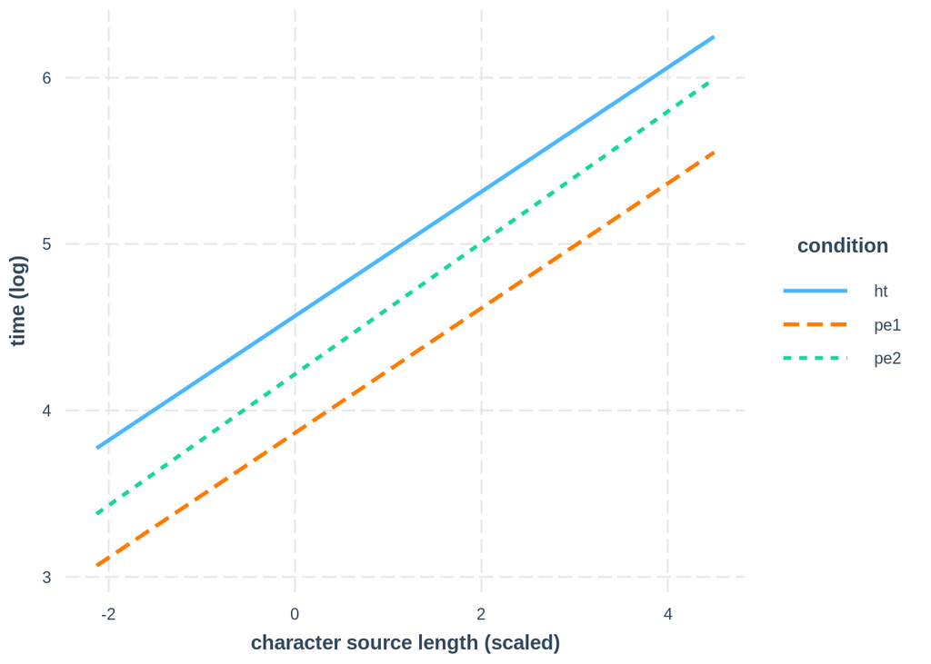

```r
iplot_te_len_task <- interact_plot(te.lmer4c, pred = src_len_chr.s, modx = task_type, y.label = "time (log)", x.label = "character source length (scaled)", legend.main = "condition")
iplot_te_len_task + theme(axis.title = element_text(family = "Arial"),
           legend.text = element_text(family = "Arial"),
           legend.title = element_text(family = "Arial"),
           strip.text = element_text(family = "Arial"),
           axis.text.x = element_text(family = "Arial"),
           axis.text.y = element_text(family = "Arial"))
```

The model with the interaction between task_type and length is worse. The interaction is not significant.

Figure: no difference for different lengths of sentences.

```r
te.lmer4d = lmer(time.l ~ src_len_chr.s + lang_id * task_type + task_type * trial.s + (1|subject_id) + (1|document_id/item_id), mydf, REML=F)
summary(te.lmer4d)
```

```
## Linear mixed model fit by maximum likelihood  ['lmerMod']
## Formula: time.l ~ src_len_chr.s + lang_id * task_type + task_type * trial.s +
##     (1 | subject_id) + (1 | document_id/item_id)
##    Data: mydf
##
##      AIC      BIC   logLik deviance df.resid
##  16870.2  17050.0  -8409.1  16818.2     7408
##
## Scaled residuals:
##     Min      1Q  Median      3Q     Max
## -6.4926 -0.5563 -0.0299  0.5629  5.5836
##
## Random effects:
##  Groups              Name        Variance Std.Dev.
##  item_id:document_id (Intercept) 0.05898  0.2429
##  document_id         (Intercept) 0.03496  0.1870
##  subject_id          (Intercept) 0.08962  0.2994
##  Residual                        0.51636  0.7186
## Number of obs: 7434, groups:
## item_id:document_id, 413; document_id, 107; subject_id, 18
##
## Fixed effects:
##                          Estimate Std. Error t value
## (Intercept)              4.926508   0.177775  27.712
## src_len_chr.s            0.381151   0.016579  22.990
## lang_idara              -0.481186   0.249502  -1.929
## lang_idita              -0.125736   0.249595  -0.504
## lang_idnld              -0.551026   0.249569  -2.208
## lang_idtur              -0.786952   0.249509  -3.154
## lang_idvie              -0.206051   0.249501  -0.826
## task_typepe1            -0.503454   0.050030 -10.063
## task_typepe2            -0.227711   0.050030  -4.552
## trial.s                  0.008108   0.019277   0.421
## lang_idara:task_typepe1 -0.093040   0.070761  -1.315
## lang_idita:task_typepe1 -0.464876   0.071340  -6.516
## lang_idnld:task_typepe1 -0.599247   0.071323  -8.402
## lang_idtur:task_typepe1 -0.219000   0.070839  -3.092
## lang_idvie:task_typepe1  0.138798   0.070752   1.962
## lang_idara:task_typepe2  0.053119   0.070761   0.751
## lang_idita:task_typepe2 -0.421917   0.071440  -5.906
## lang_idnld:task_typepe2 -0.371140   0.071132  -5.218
## lang_idtur:task_typepe2 -0.016388   0.070839  -0.231
## lang_idvie:task_typepe2  0.005426   0.070749   0.077
## task_typepe1:trial.s    -0.081041   0.021147  -3.832
## task_typepe2:trial.s    -0.045886   0.021121  -2.173
```

```
##
## Correlation matrix not shown by default, as p = 22 > 12.
## Use print(x, correlation=TRUE)  or
##     vcov(x)        if you need it
```

```r
AIC(te.lmer4b) - AIC(te.lmer4d) # 10.7
```

```
## [1] 10.71012
```

```r
AIC(te.lmer4a) - AIC(te.lmer4d) # 161
```

```
## [1] 161.5023
```

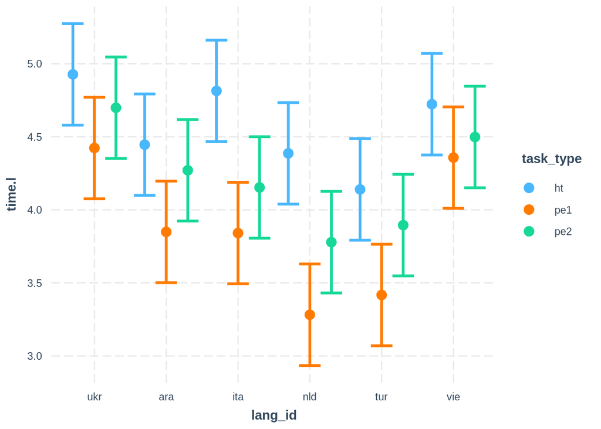

```r
iplot_te_task_trial <- cat_plot(te.lmer4b, pred = lang_id, modx = task_type)
iplot_te_task_trial + theme(axis.title = element_text(family = "Arial"),
           legend.text = element_text(family = "Arial"),
           legend.title = element_text(family = "Arial"),
           strip.text = element_text(family = "Arial"),
           axis.text.x = element_text(family = "Arial"),
           axis.text.y = element_text(family = "Arial"))
```

Both significant interactions lead to a better model than either on its own.

## 4.6 LMER: Random Effects

```r
ranef(te.lmer4d)$subject_id
```

```
##        (Intercept)
## ara_t1  0.33556514
## ara_t2 -0.38779146
## ara_t3  0.05222633
## ita_t1  0.04528517
## ita_t4  0.37110453
## ita_t5 -0.41638970
## nld_t1 -0.21099211
## nld_t2 -0.31385955
## nld_t3  0.52485166
## tur_t1 -0.42054410
## tur_t2  0.27605965
## tur_t3  0.14448445
## ukr_t1  0.07090063
## ukr_t2  0.30685264
## ukr_t3 -0.37775327
## vie_t1  0.06475274
## vie_t2  0.14645544
## vie_t3 -0.21120818
```

We can observe that the adjustments for specific subjects to the intercept are slightly different, positive for e.g. ara_T1 and ita_T1 and negative for e.g. ita_T5.

Now we check whether the addition of random slopes for subject results in a better model.

```r
te.lmer4dREML = lmer(time.l ~ src_len_chr.s + lang_id * task_type + task_type * trial.s + (1|subject_id) + (1|document_id/item_id), mydf, REML=T) # We build the previous best model with REML=T so that it can be compared to models with random slopes

#subject
te.lmer5a = lmer(time.l ~ src_len_chr.s + lang_id * task_type + task_type * trial.s + (1|subject_id) + (0+trial.s|subject_id) + (1|document_id/item_id), mydf, REML=T,
                 control = lmerControl(
                           optimizer ='optimx', optCtrl=list(method='nlminb')))
AIC(te.lmer4dREML) - AIC(te.lmer5a) #182
```

```
## [1] 181.716
```

```r
te.lmer5b = lmer(time.l ~ src_len_chr.s + lang_id * task_type + task_type * trial.s + (1|subject_id) + (1+trial.s|subject_id) + (1|document_id/item_id), mydf, REML=T,
                 control = lmerControl(
                           optimizer ='optimx', optCtrl=list(method='nlminb')))  # TODO does not converge
te.lmer5c = lmer(time.l ~ src_len_chr.s + lang_id * task_type + task_type * trial.s + (1|subject_id) + (1+task_type|subject_id) + (1|document_id/item_id), mydf, REML=T,
                 control = lmerControl(
                           optimizer ='optimx', optCtrl=list(method='nlminb'))) # TODO does not converge
```

Slope 0+trial.s for subject improves the model.

Now we check whether the addition of random slopes for item results in a better model.

```r
te.lmer6a = lmer(time.l ~ src_len_chr.s + lang_id * task_type + task_type * trial.s + (1|subject_id) + (0+trial.s|subject_id) + (1|document_id/item_id) + (0+trial.s|document_id/item_id), mydf, REML=T,
                 control = lmerControl(
                           optimizer ='optimx', optCtrl=list(method='nlminb')))

AIC(te.lmer5a) - AIC(te.lmer6a) #10
```

```
## [1] 9.543805
```

```r
te.lmer6b = lmer(time.l ~ src_len_chr.s + lang_id * task_type + task_type * trial.s + (1|subject_id) + (0+trial.s|subject_id) + (1|document_id/item_id) + (0+task_type|document_id/item_id), mydf, REML=T,
                 control = lmerControl(
                           optimizer ='optimx', optCtrl=list(method='nlminb'))) # takes very long
```

```
## boundary (singular) fit: see help('isSingular')
```

```r
AIC(te.lmer5a) - AIC(te.lmer6b) #91
```

```
## [1] 90.83022
```

```r
te.lmer6c = lmer(time.l ~ src_len_chr.s + lang_id * task_type + task_type * trial.s + (1|subject_id) + (0+trial.s|subject_id) + (1+task_type|document_id/item_id), mydf, REML=T,
                 control = lmerControl(
                           optimizer ='optimx', optCtrl=list(method='nlminb'))) # takes very long
```

```
## boundary (singular) fit: see help('isSingular')
```

```r
AIC(te.lmer6b) - AIC(te.lmer6c) #-78
```

```
## [1] -78.37808
```

```r
summary(te.lmer6b) # the best model thus far
```

```
## Linear mixed model fit by REML ['lmerMod']
## Formula: time.l ~ src_len_chr.s + lang_id * task_type + task_type * trial.s +
##     (1 | subject_id) + (0 + trial.s | subject_id) + (1 | document_id/item_id) +
##     (0 + task_type | document_id/item_id)
##    Data: mydf
## Control: lmerControl(optimizer = "optimx", optCtrl = list(method = "nlminb"))
##
## REML criterion at convergence: 16604.8
##
## Scaled residuals:
##     Min      1Q  Median      3Q     Max
## -6.1755 -0.5470 -0.0232  0.5499  5.4347
##
## Random effects:
##  Groups                Name         Variance  Std.Dev. Corr
##  item_id.document_id   task_typeht  2.598e-02 0.161196
##                        task_typepe1 1.055e-01 0.324758 0.98
##                        task_typepe2 6.883e-02 0.262359 1.00 0.97
##  item_id.document_id.1 (Intercept)  1.390e-06 0.001179
##  document_id           task_typeht  1.498e-02 0.122405
##                        task_typepe1 7.038e-02 0.265286 0.90
##                        task_typepe2 3.274e-02 0.180955 0.86 0.57
##  document_id.1         (Intercept)  1.992e-03 0.044634
##  subject_id            trial.s      1.813e-02 0.134663
##  subject_id.1          (Intercept)  1.322e-01 0.363604
##  Residual                           4.855e-01 0.696781
## Number of obs: 7434, groups:
## item_id:document_id, 413; document_id, 107; subject_id, 18
##
## Fixed effects:
##                          Estimate Std. Error t value
## (Intercept)              4.926644   0.213242  23.104
## src_len_chr.s            0.379422   0.015447  24.563
## lang_idara              -0.480429   0.300820  -1.597
## lang_idita              -0.120176   0.301163  -0.399
## lang_idnld              -0.651277   0.301144  -2.163
## lang_idtur              -0.786902   0.300827  -2.616
## lang_idvie              -0.203431   0.300823  -0.676
## task_typepe1            -0.501474   0.051801  -9.681
## task_typepe2            -0.230558   0.049701  -4.639
## trial.s                 -0.016957   0.036006  -0.471
## lang_idara:task_typepe1 -0.092531   0.068629  -1.348
## lang_idita:task_typepe1 -0.467358   0.071736  -6.515
## lang_idnld:task_typepe1 -0.443198   0.072079  -6.149
## lang_idtur:task_typepe1 -0.212613   0.068719  -3.094
## lang_idvie:task_typepe1  0.137497   0.068663   2.002
## lang_idara:task_typepe2  0.050877   0.068635   0.741
## lang_idita:task_typepe2 -0.431460   0.072260  -5.971
## lang_idnld:task_typepe2 -0.210752   0.071798  -2.935
## lang_idtur:task_typepe2 -0.020447   0.068715  -0.298
## lang_idvie:task_typepe2  0.001413   0.068638   0.021
## task_typepe1:trial.s    -0.053910   0.025863  -2.084
## task_typepe2:trial.s    -0.044981   0.022847  -1.969
```

```
##
## Correlation matrix not shown by default, as p = 22 > 12.
## Use print(x, correlation=TRUE)  or
##     vcov(x)        if you need it
```

```
## optimizer (optimx) convergence code: 1 (none)
## boundary (singular) fit: see help('isSingular')
```

## 4.7 LMER Assumptions

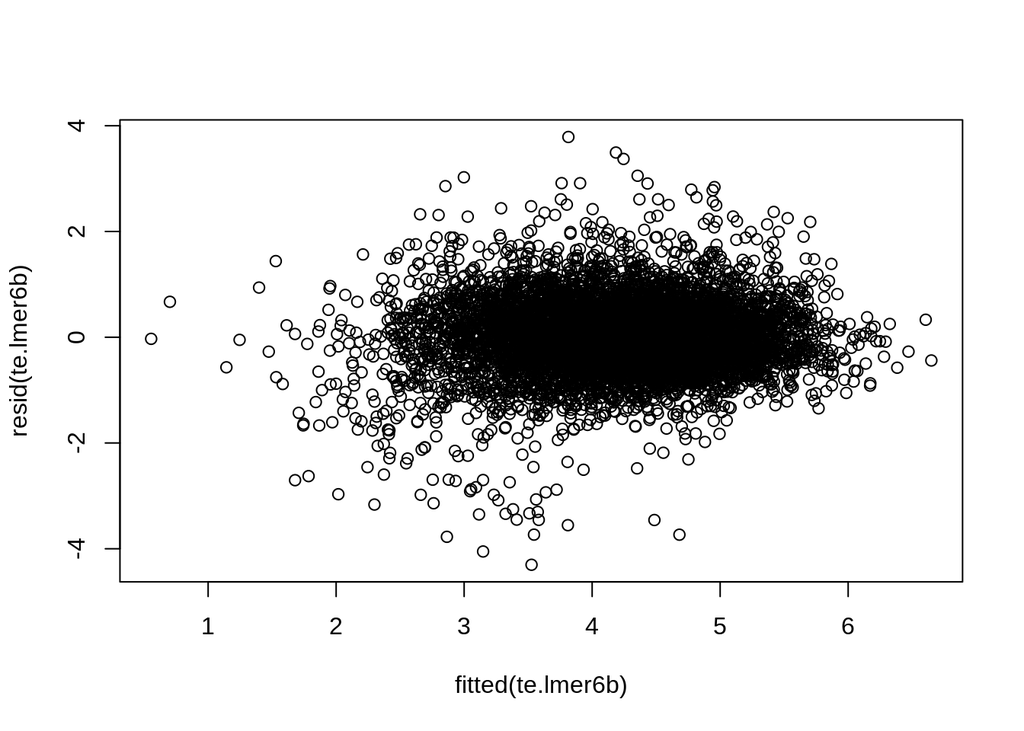

```r
# heterodasticity
par(mfrow=c(1,1), family  = "Arial")
plot(fitted(te.lmer6b), resid(te.lmer6b)) # OK
```

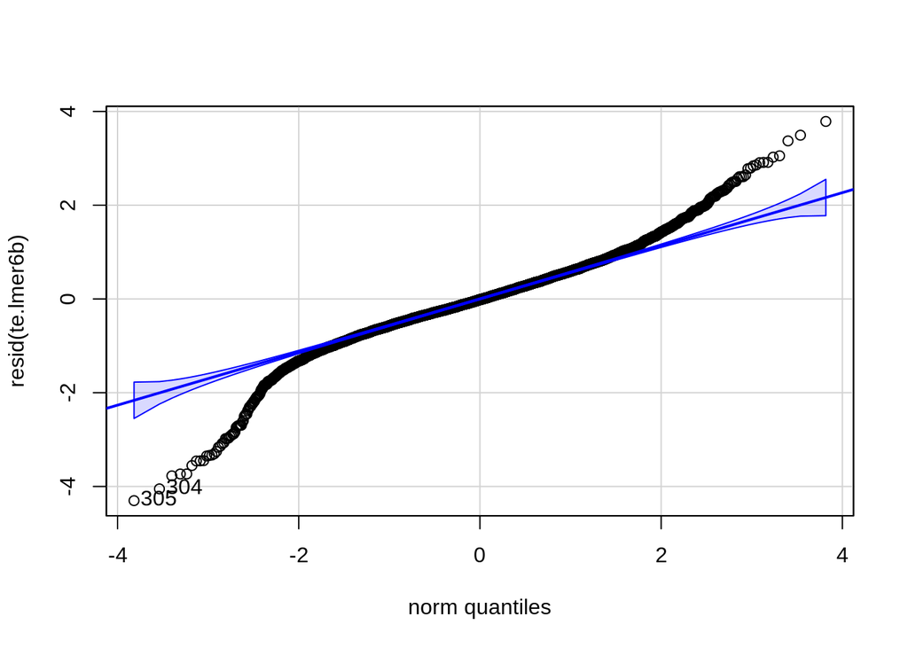

```
## [1] 305 304
```

```r
# normality
par(mfrow=c(1,1), family  = "Arial")
qqp(resid(te.lmer6b)) # not OK
```

Heterodasticity looks fine but the distribution of residuals deviates from normality.

## 4.8 Model criticism

```r
# Remove outliers
mydfno = mydf[abs(scale(resid(te.lmer6b))) < 2.5,]
dim(mydfno) - dim(mydf)
```

```
## [1] -180    0
```

```r
1 - (dim(mydfno)/dim(mydf))# 2.4% of the data points are removed
```

```
## [1] 0.02421308 0.00000000
```

```r
# Fit model on data without outliers
library(lmerTest)
te.lmer6bno = lmer(time.l ~ src_len_chr.s + lang_id * task_type + task_type * trial.s + (1|subject_id) + (0+trial.s|subject_id) + (1|document_id/item_id) + (0+task_type|document_id/item_id), mydfno, REML=T,
                 control = lmerControl(
                           optimizer ='optimx', optCtrl=list(method='nlminb')))
```

```
## boundary (singular) fit: see help('isSingular')
```

```r
# Check normality
par(mfrow=c(1,2), family="Arial")
qqp(resid(te.lmer6b))
```

```
## [1] 305 304
```

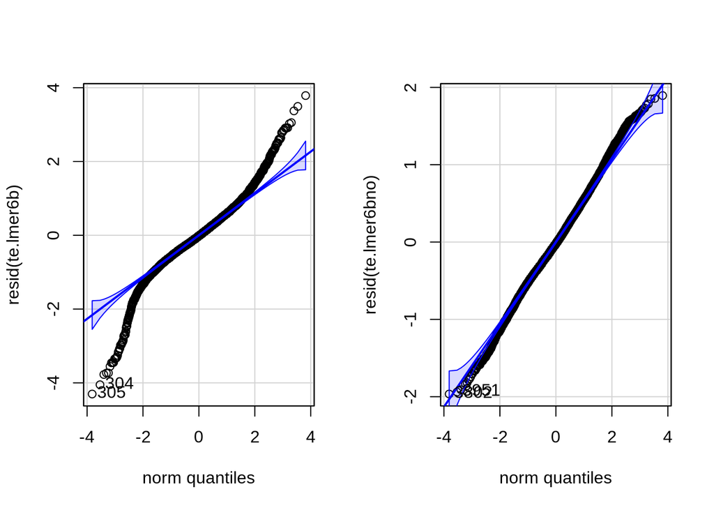

```
## 3802 3951
## 3721 3845
```

```r
qqp(resid(te.lmer6bno)) # Normality looks fine in the model without outliers.
```

```r
summary(te.lmer6b)
```

```
## Linear mixed model fit by REML ['lmerMod']
## Formula: time.l ~ src_len_chr.s + lang_id * task_type + task_type * trial.s +
##     (1 | subject_id) + (0 + trial.s | subject_id) + (1 | document_id/item_id) +
##     (0 + task_type | document_id/item_id)
##    Data: mydf
## Control: lmerControl(optimizer = "optimx", optCtrl = list(method = "nlminb"))
##
## REML criterion at convergence: 16604.8
##
## Scaled residuals:
##     Min      1Q  Median      3Q     Max
## -6.1755 -0.5470 -0.0232  0.5499  5.4347
##
## Random effects:
##  Groups                Name         Variance  Std.Dev. Corr
##  item_id.document_id   task_typeht  2.598e-02 0.161196
##                        task_typepe1 1.055e-01 0.324758 0.98
##                        task_typepe2 6.883e-02 0.262359 1.00 0.97
##  item_id.document_id.1 (Intercept)  1.390e-06 0.001179
##  document_id           task_typeht  1.498e-02 0.122405
##                        task_typepe1 7.038e-02 0.265286 0.90
##                        task_typepe2 3.274e-02 0.180955 0.86 0.57
##  document_id.1         (Intercept)  1.992e-03 0.044634
##  subject_id            trial.s      1.813e-02 0.134663
##  subject_id.1          (Intercept)  1.322e-01 0.363604
##  Residual                           4.855e-01 0.696781
## Number of obs: 7434, groups:
## item_id:document_id, 413; document_id, 107; subject_id, 18
##
## Fixed effects:
##                          Estimate Std. Error t value
## (Intercept)              4.926644   0.213242  23.104
## src_len_chr.s            0.379422   0.015447  24.563
## lang_idara              -0.480429   0.300820  -1.597
## lang_idita              -0.120176   0.301163  -0.399
## lang_idnld              -0.651277   0.301144  -2.163
## lang_idtur              -0.786902   0.300827  -2.616
## lang_idvie              -0.203431   0.300823  -0.676
## task_typepe1            -0.501474   0.051801  -9.681
## task_typepe2            -0.230558   0.049701  -4.639
## trial.s                 -0.016957   0.036006  -0.471
## lang_idara:task_typepe1 -0.092531   0.068629  -1.348
## lang_idita:task_typepe1 -0.467358   0.071736  -6.515
## lang_idnld:task_typepe1 -0.443198   0.072079  -6.149
## lang_idtur:task_typepe1 -0.212613   0.068719  -3.094
## lang_idvie:task_typepe1  0.137497   0.068663   2.002
## lang_idara:task_typepe2  0.050877   0.068635   0.741
## lang_idita:task_typepe2 -0.431460   0.072260  -5.971
## lang_idnld:task_typepe2 -0.210752   0.071798  -2.935
## lang_idtur:task_typepe2 -0.020447   0.068715  -0.298
## lang_idvie:task_typepe2  0.001413   0.068638   0.021
## task_typepe1:trial.s    -0.053910   0.025863  -2.084
## task_typepe2:trial.s    -0.044981   0.022847  -1.969
```

```
##
## Correlation matrix not shown by default, as p = 22 > 12.
## Use print(x, correlation=TRUE)  or
##     vcov(x)        if you need it
```

```
## optimizer (optimx) convergence code: 1 (none)
## boundary (singular) fit: see help('isSingular')
```

```r
summary(te.lmer6bno)
```

```
## Linear mixed model fit by REML. t-tests use Satterthwaite's method [
## lmerModLmerTest]
## Formula: time.l ~ src_len_chr.s + lang_id * task_type + task_type * trial.s +
##     (1 | subject_id) + (0 + trial.s | subject_id) + (1 | document_id/item_id) +
##     (0 + task_type | document_id/item_id)
##    Data: mydfno
## Control: lmerControl(optimizer = "optimx", optCtrl = list(method = "nlminb"))
##
## REML criterion at convergence: 13674.6
##
## Scaled residuals:
##     Min      1Q  Median      3Q     Max
## -3.3955 -0.6208 -0.0399  0.6219  3.2727
##
## Random effects:
##  Groups                Name         Variance Std.Dev. Corr
##  item_id.document_id   task_typeht  0.025994 0.16123
##                        task_typepe1 0.110199 0.33196  0.98
##                        task_typepe2 0.070324 0.26519  1.00 0.97
##  item_id.document_id.1 (Intercept)  0.000000 0.00000
##  document_id           task_typeht  0.010023 0.10012
##                        task_typepe1 0.052062 0.22817  0.86
##                        task_typepe2 0.024486 0.15648  0.86 0.57
##  document_id.1         (Intercept)  0.008607 0.09278
##  subject_id            trial.s      0.012063 0.10983
##  subject_id.1          (Intercept)  0.127708 0.35736
##  Residual                           0.335023 0.57881
## Number of obs: 7254, groups:
## item_id:document_id, 413; document_id, 107; subject_id, 18
##
## Fixed effects:
##                           Estimate Std. Error         df t value Pr(>|t|)
## (Intercept)                4.92068    0.20887   12.42580  23.559 1.09e-11 ***
## src_len_chr.s              0.37673    0.01451  431.21824  25.971  < 2e-16 ***
## lang_idara                -0.49149    0.29458   12.29137  -1.668  0.12048
## lang_idita                -0.12730    0.29483   12.33350  -0.432  0.67337
## lang_idnld                -0.67354    0.29483   12.33343  -2.284  0.04079 *
## lang_idtur                -0.82016    0.29458   12.29208  -2.784  0.01620 *
## lang_idvie                -0.23832    0.29459   12.29264  -0.809  0.43390
## task_typepe1              -0.49846    0.04402  997.97675 -11.323  < 2e-16 ***
## task_typepe2              -0.22303    0.04159 1708.03062  -5.362 9.35e-08 ***
## trial.s                   -0.01960    0.02994   25.64507  -0.655  0.51840
## lang_idara:task_typepe1   -0.11403    0.05750 6296.44274  -1.983  0.04738 *
## lang_idita:task_typepe1   -0.42497    0.06013 6346.54596  -7.067 1.75e-12 ***
## lang_idnld:task_typepe1   -0.27135    0.06104 6376.73384  -4.445 8.93e-06 ***
## lang_idtur:task_typepe1   -0.13559    0.05773 6304.48972  -2.349  0.01888 *
## lang_idvie:task_typepe1    0.12211    0.05750 6298.48830   2.124  0.03375 *
## lang_idara:task_typepe2    0.05064    0.05737 6289.71639   0.883  0.37737
## lang_idita:task_typepe2   -0.41531    0.06047 6320.45120  -6.868 7.13e-12 ***
## lang_idnld:task_typepe2   -0.15563    0.06018 6328.72464  -2.586  0.00974 **
## lang_idtur:task_typepe2    0.02763    0.05750 6295.73556   0.481  0.63086
## lang_idvie:task_typepe2    0.03047    0.05730 6288.50005   0.532  0.59489
## task_typepe1:trial.s      -0.03833    0.02281  149.86986  -1.680  0.09496 .
## task_typepe2:trial.s      -0.02344    0.01953  147.84683  -1.200  0.23193
## ---
## Signif. codes:  0 '***' 0.001 '**' 0.01 '*' 0.05 '.' 0.1 ' ' 1
```

```
##
## Correlation matrix not shown by default, as p = 22 > 12.
## Use print(x, correlation=TRUE)  or
##     vcov(x)        if you need it
```

```
## optimizer (optimx) convergence code: 0 (OK)
## boundary (singular) fit: see help('isSingular')
```

Most of the predictors and interactions that were significant remain so in the model without outliers.